# Análises TCC Aline

# Experimento 1 - Biocontrole Fúngico

## Carrega os pacotes necessários

```r
# install.packages('ggplot2', dependencies = T)
# install.packages('svglite', dependencies = T)
# install.packages('pairwiseComparisons', dependencies = T)
# install.packages('multcompView', dependencies = T)
# install.packages('ggpubr', dependencies = T)
# library(userfriendlyscience)
library(pairwiseComparisons)
library(multcompView)
library(ggplot2)
library(ggrepel)
library(svglite)
library(agricolae)
library(ggpubr)
library(dplyr)
```

Passos para realização da análise dos dados: 1 - Realizar análises exploratórias para verificar o comportamento da variável a ser analisada; 2 - Nesse passo são realizadas as análises própriamente ditas.

## Carregar os dados

```r
data1 <- read.csv("Biocontrole.csv", row.names = 1)
data1
```

|  | group | growth |
| --- | --- | --- |
| 1 | F26 | 9.0 |
| 2 | F26 | 6.0 |
| 3 | F26 | 6.0 |
| 4 | CA319 | 7.0 |
| 5 | CA319 | 9.0 |
| 6 | CA319 | 6.6 |
| 7 | CONTROLE | 9.0 |
| 8 | CONTROLE | 9.0 |
| 9 | CONTROLE | 9.0 |
| 10 | F112 | 3.6 |

[output cut: 128 more lines]

## Passo 1 - Realizar uma análise exploratória dos dados

### Plotar um histograma para verificar a distribuição possível dos dados

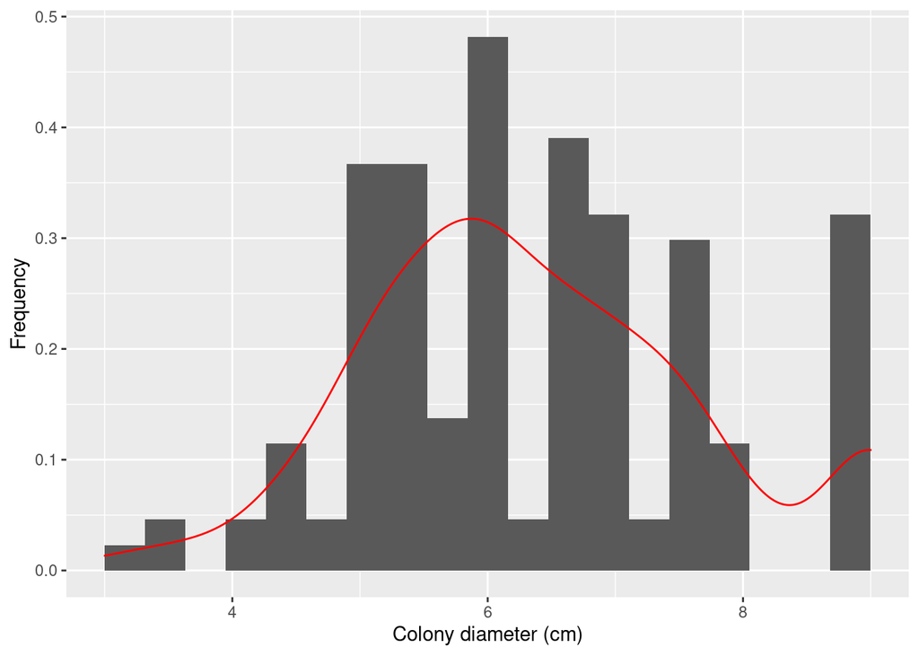

```r
hist1 <- ggplot(data1, aes(data1$growth)) +
  geom_histogram(aes(y = ..density..), bins = 20) +
  labs(x = "Colony diameter (cm)", y = "Frequency") +
  geom_density(col = 'red')


ggsave(
  plot = hist1,
  filename = "Figures/Experimento_1/Histograma1.svg",
  #height = 5,
  width = 8
)


hist1
```

### Verificar o ajuste à normalidade univariada e homogeneidade das variâncias

```r
# Normalidade univariada
shapiro.test(data1$growth)
```

```
##
##  Shapiro-Wilk normality test
##
## data:  data1$growth
## W = 0.96426, p-value = 0.001123
```

```r
# Homogeneidade das variâncias
bartlett.test(growth ~ group, data = data1)
```

```
##
##  Bartlett test of homogeneity of variances
##
## data:  growth by group
## Bartlett's K-squared = Inf, df = 44, p-value < 2.2e-16
```

## Passo 2 - Considerando que a hipótese de normalidade dos dados testada durante a análise de Shapiro-Wilk foi rejeitada (p = 0.001123), será utilizado o logarítmo na base 10 do crescimento micelial como variável resposta. Desse modo, a normalidade dos resíduos deverá ser testada para verificar a aderência dos dados ao modelo.

### Roda a análise de variância

```r
lmModel <- aov(

  # Fórmula utilizada no ajuste linear
  log10(growth) ~ group,

  # Dataset utilizado
  data = data1

)

summary.aov(lmModel)
```

```
##             Df Sum Sq Mean Sq F value   Pr(>F)
## group       44 0.8293 0.01885   5.053 2.73e-11 ***
## Residuals   93 0.3469 0.00373
## ---
## Signif. codes:  0 '***' 0.001 '**' 0.01 '*' 0.05 '.' 0.1 ' ' 1
```

### Testa a normalidade univariada dos resíduos

```r
# Normalidade univariada dos resíduos
shapiro.test(lmModel$residuals)
```

```
##
##  Shapiro-Wilk normality test
##
## data:  lmModel$residuals
## W = 0.98712, p-value = 0.2261
```

### Gera um histograma com os resíduos gerados na análise de variância

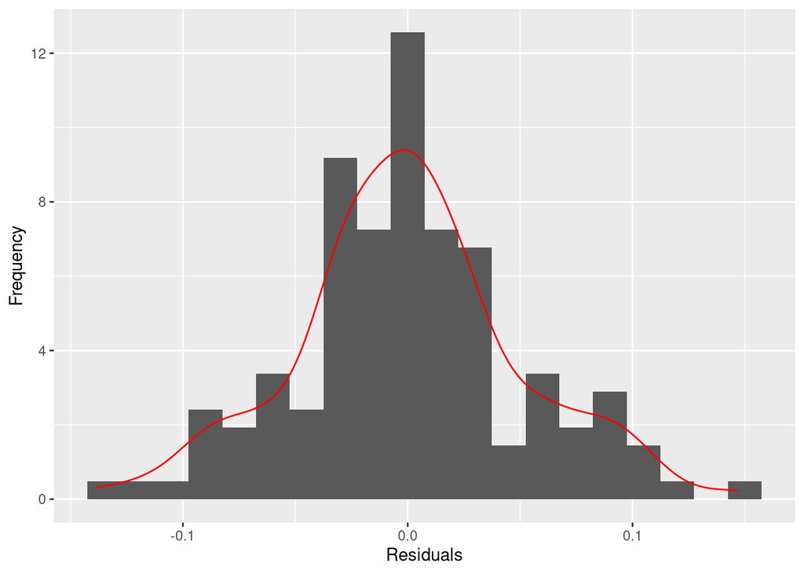

```r
res <- data.frame(
  cbind(
    lmModel$residuals,
    lmModel$model
  )
)


hist2 <- ggplot(res, aes(res$lmModel.residuals)) +
  geom_histogram(aes(y = ..density..), bins = 20) +
  labs(x = "Residuals", y = "Frequency") +
  geom_density(col = 'red')


ggsave(
  plot = hist2,
  filename = "Figures/Experimento_1/Histograma2.svg",
  width = 8
)


hist2
```

NOTA: acima pode-se observar que a distribuição dos resíduos segue uma distibuição normal e que a hipótese de aderência a normalidade não foi rejeitada, desse modo pode-se considerar os resultados da análise de variância (ANOVA) como representativos dos dados, e portanto, satisfatória.

### Gera o teste de multiplicidade

```r
hsd_pair <- LSD.test(
  lmModel,
  "group",
  group = T,
  p.adj = 'bonferroni'
)
```

### Plota o boxplot com os dados do experimento 1

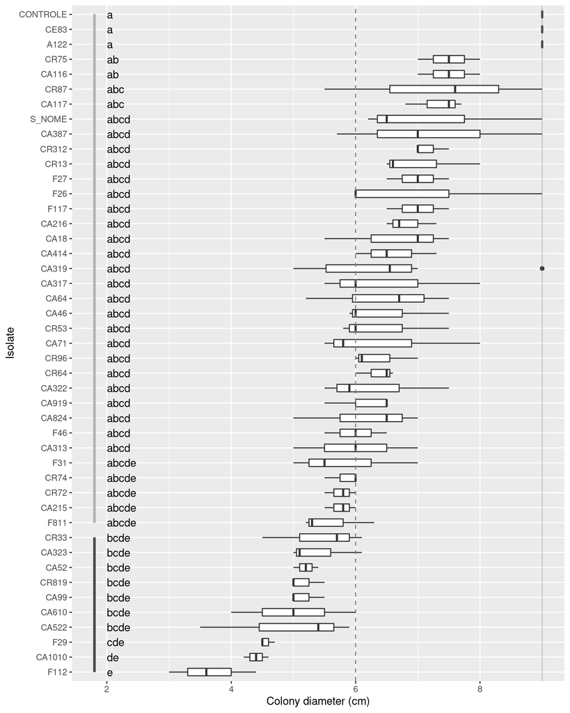

```r
stat_labels = hsd_pair$groups

stat_labels$labels = paste0(stat_labels$groups, " (", round(stat_labels$`log10(growth)` * 10, digits = 2), ")")

gp_box <- ggplot(data1, aes(x = reorder(group, growth, mean), y = growth)) +

  # Graph type
  geom_boxplot(width = 0.5) +

  # Labels
  labs(x = "Isolate", y = "Colony diameter (cm)") +

  # Theme labels position
  theme() +

  # Include multiplicity test results as text
  geom_text(
    data = hsd_pair$groups,
    mapping = aes(
      x = rownames(hsd_pair$groups),
      y = 2,
      label = stat_labels$groups
    ),
    hjust = 0
  ) +

  # Insert horizontal lines
  geom_hline(yintercept = 6, linetype = "dashed", color = "grey50") +
  geom_hline(yintercept = 9, size = 0.2, color = "grey50") +
  geom_segment(aes(x = 11, xend = 45, y = 1.8, yend = 1.8), size = 1, color = "grey70") +
  geom_segment(aes(x = 1, xend = 10, y = 1.8, yend = 1.8), size = 1, color = "grey30") +

  # Rotate right
  coord_flip()


ggsave(
  plot = gp_box,
  filename = "Figures/Experimento_1/Boxplot.svg",
  height = 10,
  width = 8
)


gp_box
```

# Experimento 2 - Estímulo do crescimento vegetal

## Carregar os dados

```r
data2 <- read.csv("CrescimentoVegetal.csv", row.names = 1)
data2
```

|  | area | rootLength | group |
| --- | --- | --- | --- |
| 1 | 16.5 | 15.0 | CONTROLE |
| 2 | 0.0 | 0.0 | CONTROLE |
| 3 | 0.0 | 0.0 | CONTROLE |
| 4 | 7.0 | 11.0 | CONTROLE |
| 5 | 5.5 | 6.5 | CONTROLE |
| 6 | 11.0 | 14.5 | CONTROLE |
| 7 | 16.5 | 14.0 | CONTROLE |
| 8 | 0.0 | 0.0 | CONTROLE |
| 9 | 14.0 | 13.0 | CR53 |
| 10 | 12.5 | 10.0 | CR53 |

[output cut: 454 more lines]

NOTA: as análises desse experimento seguem os mesmos dois passos do experimento anterior.

## Passo 1 - Realizar uma análise exploratória dos dados

### Plotar um histograma para verificar a distribuição dos dados de comprimento de raiz

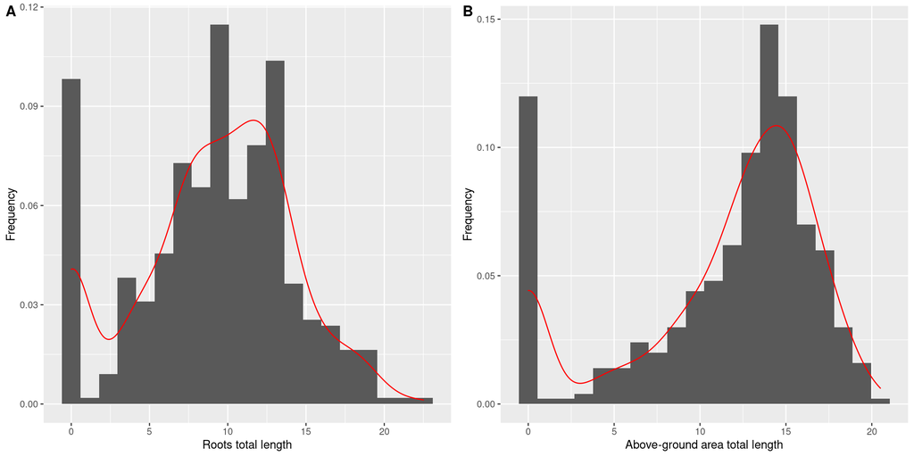

```r
hist1_2 <- ggplot(data2, aes(data2$rootLength)) +
  geom_histogram(aes(y = ..density..), bins = 20) +
  labs(x = "Roots total length", y = "Frequency") +
  geom_density(col = 'red')


hist1_3 <- ggplot(data2, aes(data2$area)) +
  geom_histogram(aes(y = ..density..), bins = 20) +
  labs(x = "Above-ground area total length", y = "Frequency") +
  geom_density(col = 'red')


multi_hist <- ggarrange(hist1_2, hist1_3,
  labels = c("A", "B"),
  ncol = 2, nrow = 1)

ggsave(
  plot = multi_hist,
  filename = "Figures/Experimento_2/MultiHistograma1.svg",
  #height = 5,
  width = 8
)


multi_hist
```

### Verificar o ajuste à normalidade univariada e homogeneidade das variâncias

```r
# Normalidade univariada
shapiro.test(data2$rootLength)
```

```
##
##  Shapiro-Wilk normality test
##
## data:  data2$rootLength
## W = 0.9649, p-value = 4.383e-09
```

```r
shapiro.test(data2$area)
```

```
##
##  Shapiro-Wilk normality test
##
## data:  data2$area
## W = 0.86448, p-value < 2.2e-16
```

```r
# Homogeneidade das variâncias
bartlett.test(area ~ group, data = data2)
```

```
##
##  Bartlett test of homogeneity of variances
##
## data:  area by group
## Bartlett's K-squared = 105.88, df = 45, p-value = 8.132e-07
```

```r
bartlett.test(rootLength ~ group, data = data2)
```

```
##
##  Bartlett test of homogeneity of variances
##
## data:  rootLength by group
## Bartlett's K-squared = 93.977, df = 45, p-value = 2.612e-05
```

```r
#data2.2 <- data2[which(data2$area >= 1, data2$rootLength >= 1), ]
data2.2 <- subset(data2, area >= 1, rootLength >= 1)
data2.2
```

|  | area | rootLength | group |
| --- | --- | --- | --- |
| 1 | 16.5 | 15.0 | CONTROLE |
| 4 | 7.0 | 11.0 | CONTROLE |
| 5 | 5.5 | 6.5 | CONTROLE |
| 6 | 11.0 | 14.5 | CONTROLE |
| 7 | 16.5 | 14.0 | CONTROLE |
| 9 | 14.0 | 13.0 | CR53 |
| 10 | 12.5 | 10.0 | CR53 |
| 11 | 1.5 | 6.0 | CR53 |
| 12 | 15.5 | 7.5 | CR53 |
| 15 | 16.0 | 18.0 | CR53 |

[output cut: 394 more lines]

### Plotar um histograma para verificar a distribuição dos dados de comprimento de raiz

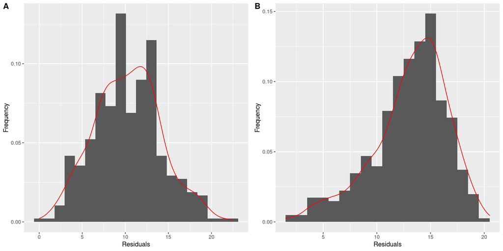

```r
hist2_2 <- ggplot(data2.2, aes(data2.2$rootLength)) +
  geom_histogram(aes(y = ..density..), bins = 20) +
  labs(x = "Residuals", y = "Frequency") +
  geom_density(col = 'red')


hist2_3 <- ggplot(data2.2, aes(data2.2$area)) +
  geom_histogram(aes(y = ..density..), bins = 20) +
  labs(x = "Residuals", y = "Frequency") +
  geom_density(col = 'red')


multi_hist2 <- ggarrange(hist2_2, hist2_3,
  labels = c("A", "B"),
  ncol = 2, nrow = 1)


ggsave(
  plot = multi_hist2,
  filename = "Figures/Experimento_2/MultiHistograma2.svg",
  #height = 5,
  width = 8
)


multi_hist2
```

### Verificar o ajuste à normalidade univariada e homogeneidade das variâncias

```r
# Normalidade univariada
shapiro.test(data2.2$rootLength)
```

```
##
##  Shapiro-Wilk normality test
##
## data:  data2.2$rootLength
## W = 0.99414, p-value = 0.1233
```

```r
shapiro.test(data2.2$area)
```

```
##
##  Shapiro-Wilk normality test
##
## data:  data2.2$area
## W = 0.95833, p-value = 2.783e-09
```

```r
# Homogeneidade das variâncias
bartlett.test(rootLength ~ group, data = data2.2)
```

```
##
##  Bartlett test of homogeneity of variances
##
## data:  rootLength by group
## Bartlett's K-squared = 65.603, df = 45, p-value = 0.02409
```

```r
bartlett.test(area ~ group, data = data2.2)
```

```
##
##  Bartlett test of homogeneity of variances
##
## data:  area by group
## Bartlett's K-squared = 66.517, df = 45, p-value = 0.02015
```

### Roda a análise de variância

```r
lmModel_2 <- aov(

  # Fórmula utilizada no ajuste linear
  rootLength ~ group,

  # Dataset utilizado
  data = data2.2

)


lmModel_3 <- aov(

  # Fórmula utilizada no ajuste linear
  area ~ group,

  # Dataset utilizado
  data = data2.2

)


summary.aov(lmModel_2)
```

```
##              Df Sum Sq Mean Sq F value   Pr(>F)
## group        45   2135   47.45   4.323 1.77e-15 ***
## Residuals   358   3930   10.98
## ---
## Signif. codes:  0 '***' 0.001 '**' 0.01 '*' 0.05 '.' 0.1 ' ' 1
```

```r
summary.aov(lmModel_3)
```

```
##              Df Sum Sq Mean Sq F value Pr(>F)
## group        45    683   15.17   1.299  0.103
## Residuals   358   4181   11.68
```

### Testa a normalidade univariada dos resíduos

```r
# Normalidade univariada dos resíduos
shapiro.test(lmModel_2$residuals)
```

```
##
##  Shapiro-Wilk normality test
##
## data:  lmModel_2$residuals
## W = 0.99367, p-value = 0.08983
```

### Gera um histograma com os resíduos gerados na análise de variância

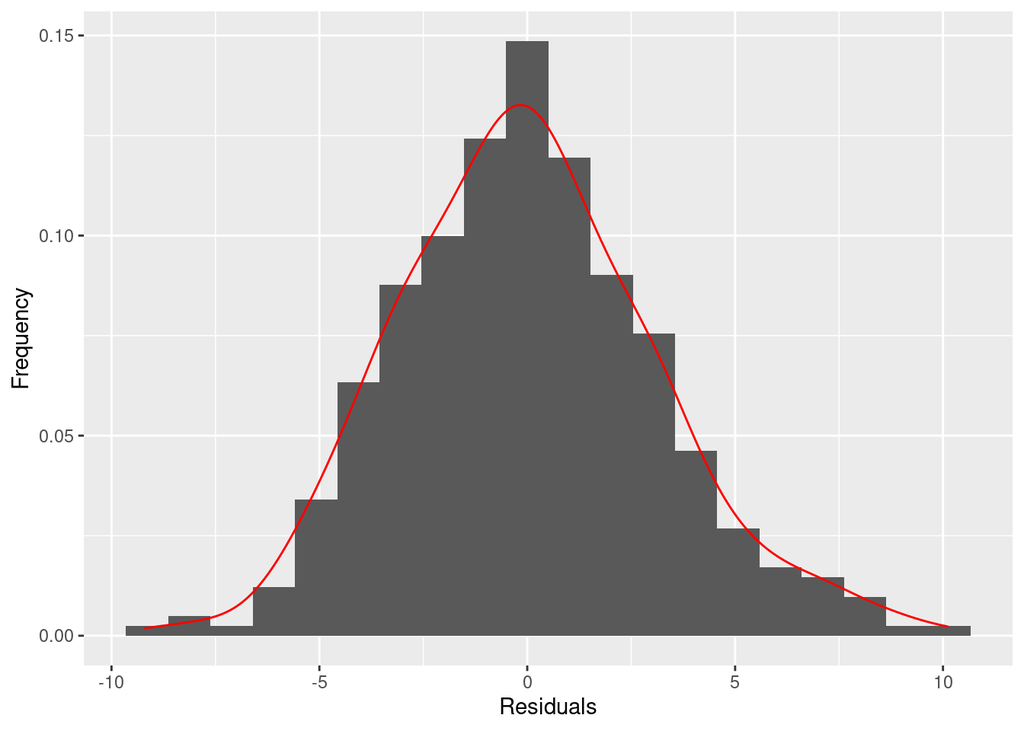

```r
res_2 <- data.frame(
  cbind(
    lmModel_2$residuals,
    lmModel_2$model
  )
)


hist3 <- ggplot(res_2, aes(res_2$lmModel_2.residuals)) +
  geom_histogram(aes(y = ..density..), bins = 20) +
  labs(x = "Residuals", y = "Frequency") +
  geom_density(col = 'red')


ggsave(
  plot = hist3,
  filename = "Figures/Experimento_2/Histograma3.svg",
  width = 8
)


hist3
```

### Gera o teste de multiplicidade

```r
hsd_pair_2 <- LSD.test(
  lmModel_2,
  "group",
  group = T,
  p.adj = 'bonferroni'
)
```

### Plota o boxplot com os dados de comprimento de raiz do experimento 2

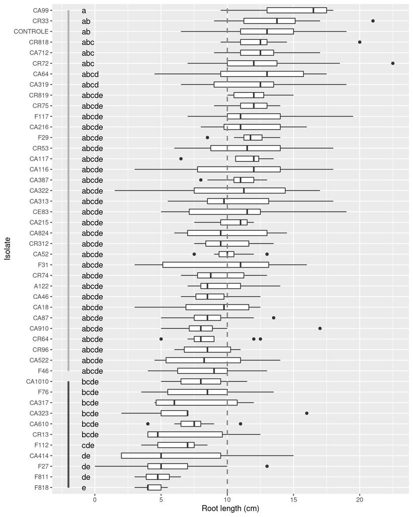

```r
stat_labels_2 = hsd_pair_2$groups

stat_labels_2$labels = paste0(stat_labels_2$groups, " (", stat_labels_2$rootLength, ")")

gp_box <- ggplot(data2.2, aes(x = reorder(group, rootLength, mean), y = rootLength)) +

  # Graph type
  geom_boxplot(width = 0.5) +

  # Labels
  labs(x = "Isolate", y = "Root length (cm)") +

  # Theme labels position
  theme() +

  # Include multiplicity test results as text
  geom_text(
    data = hsd_pair_2$groups,
    mapping = aes(
      x = rownames(hsd_pair_2$groups),
      y = -1,
      label = stat_labels_2$groups
    ),
    hjust = 0
  ) +

  # Insert horizontal lines
  geom_hline(yintercept = 10, linetype = "dashed", size = 0.8, color = "grey50") +
  geom_segment(aes(x = 12, xend = 46, y = -2, yend = -2), size = 1, color = "grey70") +
  geom_segment(aes(x = 1, xend = 11, y = -2, yend = -2), size = 1, color = "grey30") +

  # stat_summary(
  #   fun.y = mean, colour = "grey50", size = 0.5, show_guide = FALSE
  # ) +

  # Rotate right
  coord_flip()


ggsave(
  plot = gp_box,
  filename = "Figures/Experimento_2/Boxplot.svg",
  height = 10,
  width = 8
)


gp_box
```

# Final comparison

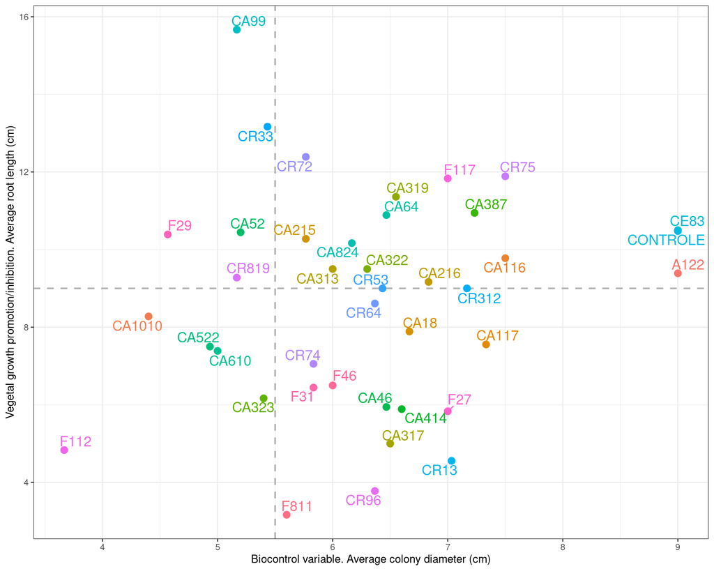

```r
full_dataset <- merge(
  data1 %>%
  group_by(group) %>%
  summarise(
    mean = mean(growth),
    sd = sd(growth),
    var = var(growth),
    min = min(growth),
    max = max(growth),
    n = n()
  ),
  data2 %>%
  group_by(group) %>%
  summarise(
    mean = mean(rootLength),
    sd = sd(rootLength),
    var = var(rootLength),
    min = min(rootLength),
    max = max(rootLength),
    n = n()
  ),
  by.x = "group",
  by.y = "group"
)


full_scatter <- ggplot(full_dataset, aes(x = mean.x, y = mean.y)) +

  # Define theme
  theme_bw() +


  # Add reference lines
  geom_hline(yintercept = 9, linetype = "dashed", size = 0.8, color = "grey70") +
  geom_vline(xintercept = 5.5, linetype = "dashed", size = 0.8, color = "grey70") +

  # Labels
  labs(
    x = "Biocontrol variable. Average colony diameter (cm)",
    y = "Vegetal growth promotion/inhibition. Average root length (cm)") +

  # Remove legends
  theme(legend.position = "none") +

  # Define geometry
  geom_point(aes(color = group), size = 3) +

  # Define labels inside graph
  geom_text_repel(aes(label = group,  color = group), size = 5)


ggsave(
  plot = full_scatter,
  filename = "Figures/ScatterplotBiocontrolVsVegetalPromotion.svg",
  height = 10,
  width = 8
)


full_scatter
```